# Assignment1_DL_lli22

## Original IMDB Example

```r
library(keras)
imdb <- dataset_imdb(num_words = 10000)
c(c(train_data, train_labels), c(test_data, test_labels)) %<-% imdb
```

```r
str(train_data[[1]])
```

```
 int [1:218] 1 14 22 16 43 530 973 1622 1385 65 ...
```

```r
train_labels[[1]]
```

```
[1] 1
```

```r
max(sapply(train_data, max))
```

```
[1] 9999
```

```r
# word_index is a dictionary mapping words to an integer index
word_index <- dataset_imdb_word_index()
# We reverse it, mapping integer indices to words
reverse_word_index <- names(word_index)
names(reverse_word_index) <- word_index
# We decode the review; note that our indices were offset by 3
# because 0, 1 and 2 are reserved indices for "padding", "start of sequence", and "unknown".
decoded_review <- sapply(train_data[[1]], function(index) {
  word <- if (index >= 3) reverse_word_index[[as.character(index - 3)]]
  if (!is.null(word)) word else "?"
})
```

```r
cat(decoded_review)
```

```
? this film was just brilliant casting location scenery story direction everyone's really suited the part they played and you could just imagine being there robert ? is an amazing actor and now the same being director ? father came from the same scottish island as myself so i loved the fact there wa…
```

```r
vectorize_sequences <- function(sequences, dimension = 10000) {
  # Create an all-zero matrix of shape (len(sequences), dimension)
  results <- matrix(0, nrow = length(sequences), ncol = dimension)
  for (i in 1:length(sequences))
    # Sets specific indices of results[i] to 1s
    results[i, sequences[[i]]] <- 1
  results
}
# Our vectorized training data
x_train <- vectorize_sequences(train_data)
# Our vectorized test data
x_test <- vectorize_sequences(test_data)
```

Here’s what our samples look like now:

```r
str(x_train[1,])
```

```
 num [1:10000] 1 1 0 1 1 1 1 1 1 0 ...
```

We should also vectorize our labels, which is straightforward:

```r
# Our vectorized labels
y_train <- as.numeric(train_labels)
y_test <- as.numeric(test_labels)
```

```r
library(keras)
model <- keras_model_sequential() %>%
  layer_dense(units = 16, activation = "relu", input_shape = c(10000)) %>%
  layer_dense(units = 16, activation = "relu") %>%
  layer_dense(units = 1, activation = "sigmoid")
```

```r
model %>% compile(
  optimizer = "rmsprop",
  loss = "binary_crossentropy",
  metrics = c("accuracy")
)
```

```r
model %>% compile(
  optimizer = optimizer_rmsprop(lr=0.001),
  loss = "binary_crossentropy",
  metrics = c("accuracy")
)
```

```r
model %>% compile(
  optimizer = optimizer_rmsprop(lr = 0.001),
  loss = loss_binary_crossentropy,
  metrics = metric_binary_accuracy
)
```

```r
val_indices <- 1:10000
x_val <- x_train[val_indices,]
partial_x_train <- x_train[-val_indices,]
y_val <- y_train[val_indices]
partial_y_train <- y_train[-val_indices]
```

```r
model %>% compile(
  optimizer = "rmsprop",
  loss = "binary_crossentropy",
  metrics = c("accuracy")
)
history <- model %>% fit(
  partial_x_train,
  partial_y_train,
  epochs = 20,
  batch_size = 512,
  validation_data = list(x_val, y_val)
)
```

On CPU, this will take less than two seconds per epoch – training is over in 20 seconds. At the end of every epoch, there is a slight pause as the model computes its loss and accuracy on the 10,000 samples of the validation data.

Note that the call to `fit()` returns a `history` object. Let’s take a look at it:

```r
str(history)
```

[output not shown]

The `history` object includes various parameters used to fit the model (`history$params`) as well as data for each of the metrics being monitored (`history$metrics`).

The `history` object has a `plot()` method that enables us to visualize the training and validation metrics by epoch:

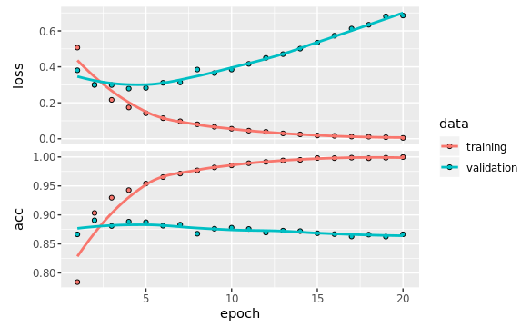

```r
plot(history)
```

```r
model <- keras_model_sequential() %>%
  layer_dense(units = 16, activation = "relu", input_shape = c(10000)) %>%
  layer_dense(units = 16, activation = "relu") %>%
  layer_dense(units = 1, activation = "sigmoid")
model %>% compile(
  optimizer = "rmsprop",
  loss = "binary_crossentropy",
  metrics = c("accuracy")
)
model %>% fit(x_train, y_train, epochs = 4, batch_size = 512)
results <- model %>% evaluate(x_test, y_test)
```

```r
results
```

```
$loss
[1] 0.3051609

$acc
[1] 0.8778
```

```r
model %>% predict(x_test[1:10,])
```

```
            [,1]
 [1,] 0.17827229
 [2,] 0.99992776
 [3,] 0.72161072
 [4,] 0.62113965
 [5,] 0.92344445
 [6,] 0.73380995
 [7,] 0.99824893
 [8,] 0.01484489
 [9,] 0.95619655
[10,] 0.97264963
```

## Changing and comparition.

### Try four layers, hidden units 64, mse loss function and tanh activation.

```r
library(keras)
model <- keras_model_sequential() %>%
  layer_dense(units = 64, activation = "tanh", input_shape = c(10000)) %>%
  layer_dense(units = 64, activation = "tanh") %>%
  layer_dense(units = 64, activation = "tanh") %>%
  layer_dense(units = 1, activation = "sigmoid")
```

### Loss function

```r
model %>% compile(
  optimizer = "rmsprop",
  loss = "mse",
  metrics = c("accuracy")
)
```

### Validating our approach

```r
val_indices <- 1:10000
x_val <- x_train[val_indices,]
partial_x_train <- x_train[-val_indices,]
y_val <- y_train[val_indices]
partial_y_train <- y_train[-val_indices]
```

### Train our model for 20 epochs (20 iterations over all samples in the `x_train` and `y_train` tensors), in mini-batches of 512 samples.

```r
model %>% compile(
  optimizer = "rmsprop",
  loss = "mse",
  metrics = c("accuracy")
)
history <- model %>% fit(
  partial_x_train,
  partial_y_train,
  epochs = 20,
  batch_size = 512,
  validation_data = list(x_val, y_val)
)
```

### Object

```r
str(history)
```

```
List of 2
 $ params :List of 8
  ..$ metrics           : chr [1:4] "loss" "acc" "val_loss" "val_acc"
  ..$ epochs            : int 20
  ..$ steps             : NULL
  ..$ do_validation     : logi TRUE
  ..$ samples           : int 15000
  ..$ batch_size        : int 512
  ..$ verbose           : int 1
  ..$ validation_samples: int 10000
 $ metrics:List of 4
  ..$ acc     : num [1:20] 0.786 0.909 0.932 0.95 0.955 ...
  ..$ loss    : num [1:20] 0.1516 0.0689 0.0524 0.0399 0.0363 ...
  ..$ val_acc : num [1:20] 0.878 0.886 0.86 0.882 0.876 ...
  ..$ val_loss: num [1:20] 0.0909 0.0837 0.1056 0.0934 0.097 ...
 - attr(*, "class")= chr "keras_training_history"
```

### Plot

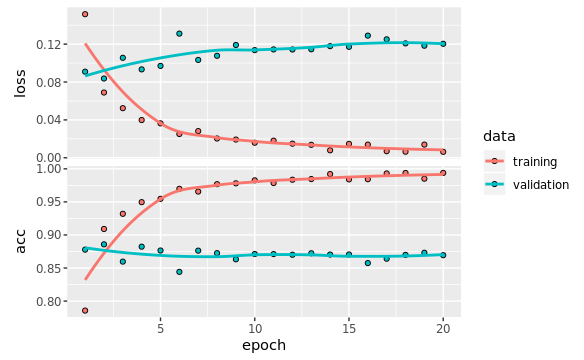

```r
plot(history)
```

### Using a trained network to generate predictions on new data

```r
model %>% predict(x_test[1:10,])
```

```
              [,1]
 [1,] 8.326966e-05
 [2,] 9.999939e-01
 [3,] 9.999200e-01
 [4,] 9.705427e-01
 [5,] 9.999340e-01
 [6,] 9.995284e-01
 [7,] 9.999894e-01
 [8,] 1.434222e-05
 [9,] 9.945179e-01
[10,] 9.999902e-01
```

## Possible Updating model: Generalization and Dropout.

### Generalization

```r
library(keras)
model <- keras_model_sequential() %>%
  layer_dense(units = 64, activation = "tanh", input_shape = c(10000),
              kernel_regularizer = regularizer_l1(l = 0.001)) %>%
  layer_dense(units = 64, activation = "tanh",
              kernel_regularizer = regularizer_l1(l = 0.001)) %>%
  layer_dense(units = 64, activation = "tanh",
              kernel_regularizer = regularizer_l1(l = 0.001)) %>%
  layer_dense(units = 1, activation = "sigmoid")
```

```r
model %>% compile(
  optimizer = "rmsprop",
  loss = "mse",
  metrics = c("accuracy")
)
```

```r
val_indices <- 1:10000
x_val <- x_train[val_indices,]
partial_x_train <- x_train[-val_indices,]
y_val <- y_train[val_indices]
partial_y_train <- y_train[-val_indices]
```

```r
model %>% compile(
  optimizer = "rmsprop",
  loss = "mse",
  metrics = c("accuracy")
)
history <- model %>% fit(
  partial_x_train,
  partial_y_train,
  epochs = 20,
  batch_size = 512,
  validation_data = list(x_val, y_val)
)
```

```r
str(history)
```

```
List of 2
 $ params :List of 8
  ..$ metrics           : chr [1:4] "loss" "acc" "val_loss" "val_acc"
  ..$ epochs            : int 20
  ..$ steps             : NULL
  ..$ do_validation     : logi TRUE
  ..$ samples           : int 15000
  ..$ batch_size        : int 512
  ..$ verbose           : int 1
  ..$ validation_samples: int 10000
 $ metrics:List of 4
  ..$ acc     : num [1:20] 0.684 0.807 0.834 0.841 0.86 ...
  ..$ loss    : num [1:20] 2.486 1.07 0.889 0.748 0.632 ...
  ..$ val_acc : num [1:20] 0.775 0.845 0.821 0.85 0.865 ...
  ..$ val_loss: num [1:20] 1.179 0.962 0.822 0.685 0.586 ...
 - attr(*, "class")= chr "keras_training_history"
```

### Comparition of Generalization and basic model.

The results shows the generalization doesn’t work well on this case. the highest accuracy and smallest loss is (0.8961, 0.4588), so we can try other model to try to update.

### Dropout

```r
library(keras)
model <- keras_model_sequential() %>%
  layer_dense(units = 64, activation = "tanh", input_shape = c(10000)) %>%
  layer_dropout(0.6) %>%
  layer_dense(units = 64, activation = "tanh") %>%
  layer_dropout(0.6) %>%
  layer_dense(units = 64, activation = "tanh") %>%
  layer_dropout(0.6) %>%
  layer_dense(units = 1, activation = "sigmoid")
```

```r
model %>% compile(
  optimizer = "rmsprop",
  loss = "mse",
  metrics = c("accuracy")
)
```

```r
val_indices <- 1:10000
x_val <- x_train[val_indices,]
partial_x_train <- x_train[-val_indices,]
y_val <- y_train[val_indices]
partial_y_train <- y_train[-val_indices]
```

```r
model %>% compile(
  optimizer = "rmsprop",
  loss = "mse",
  metrics = c("accuracy")
)
history <- model %>% fit(
  partial_x_train,
  partial_y_train,
  epochs = 20,
  batch_size = 512,
  validation_data = list(x_val, y_val)
)
```

```r
str(history)
```

```
List of 2
 $ params :List of 8
  ..$ metrics           : chr [1:4] "loss" "acc" "val_loss" "val_acc"
  ..$ epochs            : int 20
  ..$ steps             : NULL
  ..$ do_validation     : logi TRUE
  ..$ samples           : int 15000
  ..$ batch_size        : int 512
  ..$ verbose           : int 1
  ..$ validation_samples: int 10000
 $ metrics:List of 4
  ..$ acc     : num [1:20] 0.728 0.865 0.903 0.916 0.923 ...
  ..$ loss    : num [1:20] 0.1786 0.1009 0.0764 0.0643 0.0604 ...
  ..$ val_acc : num [1:20] 0.845 0.886 0.889 0.888 0.888 ...
  ..$ val_loss: num [1:20] 0.1102 0.0848 0.0847 0.087 0.0882 ...
 - attr(*, "class")= chr "keras_training_history"
```

### Comparition

The results shows the dropout doesn’t work well on this case. the highest accuracy and smallest loss is (0.9818, 0.0161), but this method is better than the generalization.

### Possible reasons of non upgraded

The reasons could be the basic model is better than the orignal model since it added layer and hidden units. we can check generalization and dropout method by cheking the orginial model to see if they get better result. The purpose of those work is to find a better and better model to forcast the possible data in the future.